# Leaderboards for Subchallenge IV

Attila Gabor

11/25/2019

# 1 Overview

Here we report some statistics about subchallenge IV and evaluate the leaderboard.

Some statistics about challenge IV:

- the number of total submissions: 83.
- the number of submissions per rounds
  - round 1: 13
  - round 2: 41
  - round 3: 29
- the number of teams participated in this sub challenge: 25

Nice improvement from roun 1 to round 2 and final round.

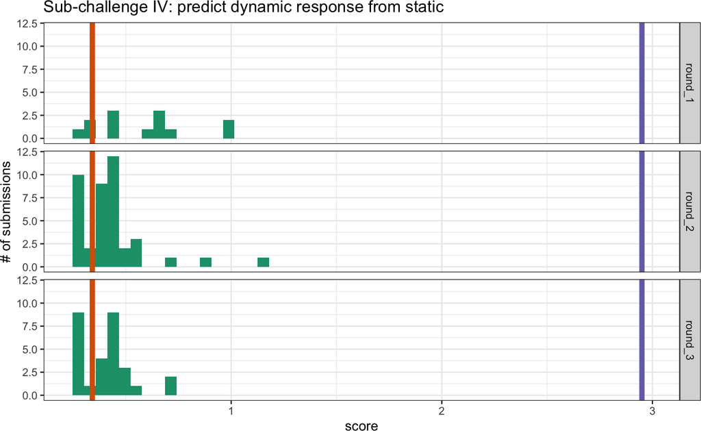

# 2 Leaderboards

Next figure shows all the submissions. We report the scores of each team, ordered by their last submission as we agreed to rank them. The shape of the points indicate in which round they submitted that predictions.

Some teams did not submit in the final rounds in some cases the final submissions were worst than the previous ones.

Here we go though the best teams as they are ranked on the figure. In all cases the write-ups need to be checked.

- The top 3 places are stable.
- `dreamskys` has a good prediction in round 3 that would be place 4, but not the latest submission.

TODO: decide what to do with the teams that didnt submit in the final round. This could influence the 3rd place.

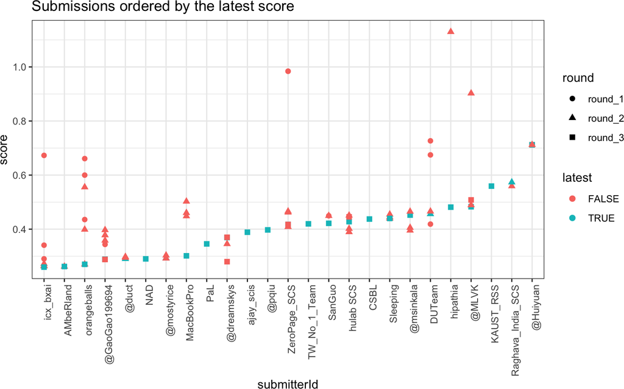

## 2.1 Strict leaderboard

- only teams with submission to round 3
- judging by their latest submission.

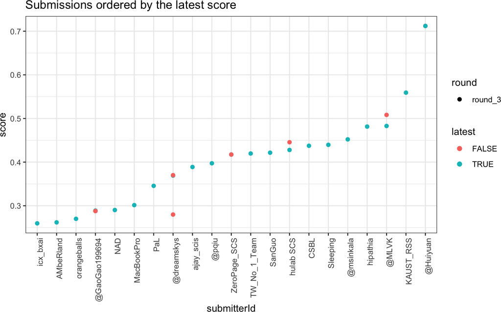

```
## # A tibble: 21 x 3
##    createdOn           submitterId   score
##    <dttm>              <chr>         <dbl>
##  1 2019-11-15 12:46:00 icx_bxai      0.260
##  2 2019-11-10 14:32:00 AMbeRland     0.262
##  3 2019-11-15 10:49:00 orangeballs   0.270
##  4 2019-11-14 11:54:00 @GaoGao199694 0.289
##  5 2019-11-08 20:35:00 NAD           0.290
##  6 2019-11-14 10:00:00 MacBookPro    0.301
##  7 2019-11-10 22:28:00 PaL           0.346
##  8 2019-11-12 04:51:00 @dreamskys    0.369
##  9 2019-11-07 06:05:00 ajay_scis     0.389
## 10 2019-11-01 02:14:00 @pqiu         0.397
## 11 2019-11-14 12:25:00 ZeroPage_SCS  0.417
## 12 2019-11-10 20:56:00 TW_No_1_Team  0.420
## 13 2019-11-13 04:54:00 SanGuo        0.422
## 14 2019-11-16 01:18:00 hulab SCS     0.428
## 15 2019-11-16 12:46:00 CSBL          0.437
## # … with 6 more rows
```

## 2.2 Leaderboard based on best score

- teams with any submission
- judging by the best score.

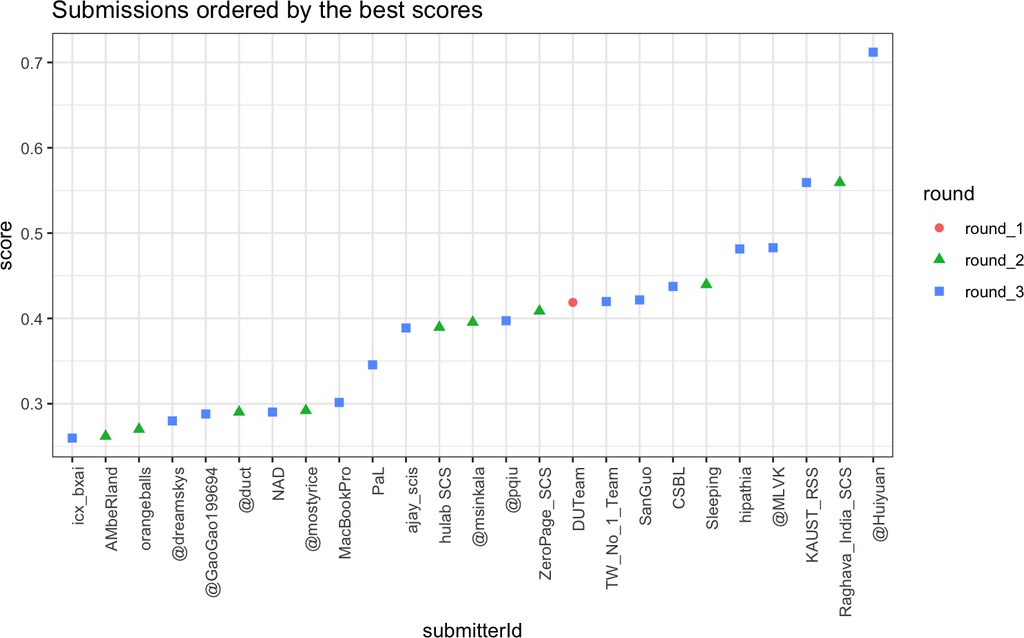

```
## # A tibble: 25 x 4
##    createdOn           submitterId       score round
##    <dttm>              <chr>             <dbl> <chr>
##  1 2019-11-15 12:46:00 icx_bxai          0.260 round_3
##  2 2019-10-30 10:16:00 AMbeRland         0.262 round_2
##  3 2019-10-30 11:01:00 orangeballs       0.270 round_2
##  4 2019-11-12 04:50:00 @dreamskys        0.280 round_3
##  5 2019-11-14 07:51:00 @GaoGao199694     0.288 round_3
##  6 2019-10-29 12:20:00 @duct             0.290 round_2
##  7 2019-11-08 20:35:00 NAD               0.290 round_3
##  8 2019-10-24 09:08:00 @mostyrice        0.292 round_2
##  9 2019-11-14 10:00:00 MacBookPro        0.301 round_3
## 10 2019-11-10 22:28:00 PaL               0.346 round_3
## 11 2019-11-07 06:05:00 ajay_scis         0.389 round_3
## 12 2019-10-30 10:22:00 hulab SCS         0.390 round_2
## 13 2019-10-13 12:36:00 @msinkala         0.395 round_2
## 14 2019-11-01 02:14:00 @pqiu             0.397 round_3
## 15 2019-10-27 03:45:00 ZeroPage_SCS      0.409 round_2
## 16 2019-09-28 07:55:00 DUTeam            0.419 round_1
## 17 2019-11-10 20:56:00 TW_No_1_Team      0.420 round_3
## 18 2019-11-13 04:54:00 SanGuo            0.422 round_3
## 19 2019-11-16 12:46:00 CSBL              0.437 round_3
## 20 2019-10-30 05:33:00 Sleeping          0.440 round_2
## 21 2019-11-14 02:27:00 hipathia          0.481 round_3
## 22 2019-10-31 01:28:00 @MLVK             0.483 round_3
## 23 2019-11-05 22:50:00 KAUST_RSS         0.559 round_3
## 24 2019-10-17 09:26:00 Raghava_India_SCS 0.559 round_2
## 25 2019-11-01 18:11:00 @Huiyuan          0.712 round_3
```

## 2.3 Leaderboard based on latest submission

- teams with any submission
- judging by the latest score.

[figure not shown]

```
## # A tibble: 25 x 5
##    createdOn           submitterId       score round   latest
##    <dttm>              <chr>             <dbl> <chr>   <lgl>
##  1 2019-11-15 12:46:00 icx_bxai          0.260 round_3 TRUE
##  2 2019-11-10 14:32:00 AMbeRland         0.262 round_3 TRUE
##  3 2019-11-15 10:49:00 orangeballs       0.270 round_3 TRUE
##  4 2019-11-14 11:54:00 @GaoGao199694     0.289 round_3 TRUE
##  5 2019-10-29 12:20:00 @duct             0.290 round_2 TRUE
##  6 2019-11-08 20:35:00 NAD               0.290 round_3 TRUE
##  7 2019-10-29 10:29:00 @mostyrice        0.293 round_2 TRUE
##  8 2019-11-14 10:00:00 MacBookPro        0.301 round_3 TRUE
##  9 2019-11-10 22:28:00 PaL               0.346 round_3 TRUE
## 10 2019-11-12 04:51:00 @dreamskys        0.369 round_3 TRUE
## 11 2019-11-07 06:05:00 ajay_scis         0.389 round_3 TRUE
## 12 2019-11-01 02:14:00 @pqiu             0.397 round_3 TRUE
## 13 2019-11-14 12:25:00 ZeroPage_SCS      0.417 round_3 TRUE
## 14 2019-11-10 20:56:00 TW_No_1_Team      0.420 round_3 TRUE
## 15 2019-11-13 04:54:00 SanGuo            0.422 round_3 TRUE
## 16 2019-11-16 01:18:00 hulab SCS         0.428 round_3 TRUE
## 17 2019-11-16 12:46:00 CSBL              0.437 round_3 TRUE
## 18 2019-11-15 02:59:00 Sleeping          0.440 round_3 TRUE
## 19 2019-11-02 18:28:00 @msinkala         0.452 round_3 TRUE
## 20 2019-10-28 02:52:00 DUTeam            0.456 round_2 TRUE
## 21 2019-11-14 02:27:00 hipathia          0.481 round_3 TRUE
## 22 2019-10-31 01:28:00 @MLVK             0.483 round_3 TRUE
## 23 2019-11-05 22:50:00 KAUST_RSS         0.559 round_3 TRUE
## 24 2019-10-28 09:18:00 Raghava_India_SCS 0.574 round_2 TRUE
## 25 2019-11-14 09:36:00 @Huiyuan          0.712 round_3 TRUE
```